# BSMM-lab-2

BSMM 8740 Fall 2023

Author

Anubhuti Talwar

Published

September 29, 2023

## Setup

Load packages and data:

```r
library(dplyr)
library(readr)
library(magrittr)
library(tidyverse)
```

```r
# load the data #
the_tate <- readr::read_delim("data/the-tate-collection.csv", ";", escape_double = FALSE, trim_ws = TRUE)
the_tate_artists <- readr::read_csv("data/the-tate-artists.csv")
```

## Exercises

### Exercise 1

```r
# Print the result #
the_tate <- read_delim("data/the-tate-collection.csv", ";", escape_double = FALSE, trim_ws = TRUE)
the_tate_artists <- read_csv("data/the-tate-artists.csv")
print(the_tate)
```

```
# A tibble: 69,201 × 20
      id accession_number artist       artistRole artistId title dateText medium
   <dbl> <chr>            <chr>        <chr>         <dbl> <chr> <chr>    <chr>
 1 20400 P77527           Charlton, A… artist          891 [no … 1991     Scree…
 2 20618 P77580           Artschwager… artist          669 Inte… 1972     Scree…
 3 20830 P77612           Marden, Bri… artist         1578 [no … 1971     Etchi…
 4 21086 P77680           Francis, Ma… artist         2311 Unti… 1994     Monot…
 5 21163 P77699           Self, Colin  artist         1922 Powe… 1968     Scree…
 6 21157 P77704           Woodrow, Bi… artist         2170 [ind… 1994     Linoc…
 7 21153 P77708           Woodrow, Bi… artist         2170 Iron  1994     Linoc…
 8 21210 P77731           Sherman, Ci… artist         1938 Unti… 1982     Photo…
 9 21271 P77738           Wilding, Al… artist         2146 [no … 1994     Etchi…
10 21405 P77748           Struth, Tho… artist         2339 Vico… 1988     Photo…
# ℹ 69,191 more rows
# ℹ 12 more variables: creditLine <chr>, year <dbl>, acquisitionYear <dbl>,
#   dimensions <chr>, width <dbl>, height <dbl>, depth <dbl>, units <chr>,
#   inscription <chr>, thumbnailCopyright <chr>, thumbnailUrl <chr>, url <chr>
```

```r
# Calculate the no. of unique artists represented in the collection
unique_artists_count <- the_tate |>
 select(artist) |>
  distinct() |>
  nrow()
unique_artists_count
```

```
[1] 3336
```

```r
# Total no. of rows and columns in the the_tate dataset
tate_dimensions <- dim(the_tate)
tate_summary <- the_tate |>
  summarize(
    Totalthe_tate = n(),               # Total no. of the_tate
    UniqueArtists = unique_artists_count, # Number of unique artists
    MinYear = min(year, na.rm = TRUE),  # Minimum year in the collection
    MaxYear = max(year, na.rm = TRUE), # Maximum year in the collection
    MinacquisitionYear = min(acquisitionYear, na.rm = TRUE), # Min Acqusition year
    MaxacquisitionYear = max(acquisitionYear, na.rm = TRUE) # Max Acqusition year
)
# The summary
print(tate_summary)
```

```
# A tibble: 1 × 6
  Totalthe_tate UniqueArtists MinYear MaxYear MinacquisitionYear
          <int>         <int>   <dbl>   <dbl>              <dbl>
1         69201          3336    1545    2012               1823
# ℹ 1 more variable: MaxacquisitionYear <dbl>
```

### Exercise 2

```r
# Load the  libraries #
library(tibble)
library(dplyr)

#Introduce the_tate and the_tate_artists dataset using DataExplorer#

DataExplorer::introduce(the_tate)
```

```
# A tibble: 1 × 9
   rows columns discrete_columns continuous_columns all_missing_columns
  <int>   <int>            <int>              <int>               <int>
1 69201      20               13                  7                   0
# ℹ 4 more variables: total_missing_values <int>, complete_rows <int>,
#   total_observations <int>, memory_usage <dbl>
```

```r
DataExplorer::introduce(the_tate_artists)
```

```
# A tibble: 1 × 9
   rows columns discrete_columns continuous_columns all_missing_columns
  <int>   <int>            <int>              <int>               <int>
1  3532       9                6                  3                   0
# ℹ 4 more variables: total_missing_values <int>, complete_rows <int>,
#   total_observations <int>, memory_usage <dbl>
```

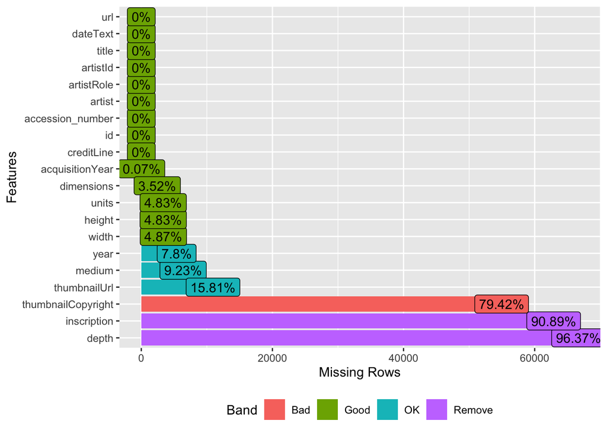

```r
DataExplorer::plot_missing(the_tate)
```

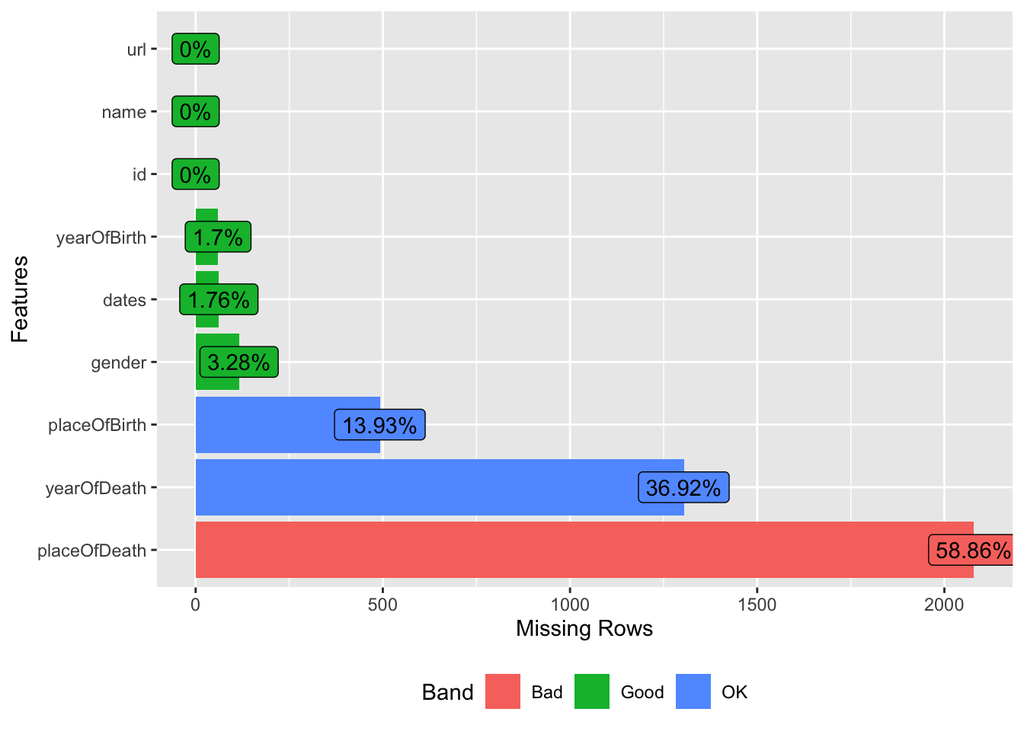

```r
DataExplorer::plot_missing(the_tate_artists)
```

```r
works_with_missing_year <- sum(is.na(the_tate$year))
print(works_with_missing_year)
```

```
[1] 5397
```

```r
# Filter the 'the_tate' dataset to select rows with missing 'year' values #
the_tate|>dplyr::filter(is.na(year))|>dplyr::distinct(artist)
```

```
# A tibble: 461 × 1
   artist
   <chr>
 1 Burne-Jones, Sir Edward Coley, Bt
 2 Houghton, Arthur Boyd
 3 Jones, George
 4 Poynter, Sir Edward
 5 Varley, John
 6 Stothard, Thomas
 7 Hunt, William Henry
 8 Smetham, James
 9 Keene, Charles Samuel
10 Swan, John Macallan
# ℹ 451 more rows
```

```r
artists_with_missing_date <- the_tate |>
  filter(is.na(year)) |>
  distinct(artist) |>
  nrow()
print(artists_with_missing_date)
```

```
[1] 461
```

```r
#Filter the tate_dataset to select rows with missing year values#
artist_missing_year_count <- the_tate|>dplyr::filter(is.na(year)) |>
  group_by(artist) |>
  summarise(missing_year = sum(is.na(year))) |>
  arrange(desc(missing_year)) |> #Arrange the results in descending order of missing 'year' counts#
  as_tibble()

print(artist_missing_year_count)
```

```
# A tibble: 461 × 2
   artist                         missing_year
   <chr>                                 <int>
 1 Jones, George                          1039
 2 Turner, Joseph Mallord William          343
 3 British (?) School                      325
 4 Cozens, Alexander                       209
 5 Dance-Holland, Sir Nathaniel            163
 6 Stothard, Thomas                        158
 7 Flaxman, John                           136
 8 Barlow, Francis                         106
 9 Davis, John Scarlett                     83
10 Hunt, William Henry                      78
# ℹ 451 more rows
```

```r
artists_with_missing_year <- nrow(artist_missing_year_count)

print(artists_with_missing_year)
```

```
[1] 461
```

```r
artist_missing_year_count <- artist_missing_year_count |> # Calculate the percentage of missing 'year' values for each artist #
  mutate(percentage = (missing_year / works_with_missing_year) * 100)

artist_missing_year_count <- artist_missing_year_count |>
  mutate(cumulative_percentage = cumsum(percentage)) # Calculate the cumulative percentage of missing 'year' values #

artists_to_resolve_50_percent <- min(which(artist_missing_year_count$cumulative_percentage >= 50))

print(artists_to_resolve_50_percent)
```

```
[1] 11
```

How number of works with missing date is 5397.

The number of artists whose works have missing year is 461.

It would require resolving missing year data for only 11 artists resolve resolve at least 50% of the missing data.

The missing year data likely to be classified as MAR.

### Exercise 3

```r
# Calculate the count of works for each artist in the 'the_tate' dataset #
artist_work_counts <- the_tate |>
  group_by(artist) |>
  summarize(title = n()) |>
  arrange(desc(title))

# Extract and display the top 10 artists with the most works #
top_10_artists <- artist_work_counts |>
  slice_head(n = 10)

print(artist_work_counts)
```

```
# A tibble: 3,336 × 2
   artist                         title
   <chr>                          <int>
 1 Turner, Joseph Mallord William 39389
 2 Jones, George                   1046
 3 Moore, Henry, OM, CH             623
 4 Daniell, William                 612
 5 Beuys, Joseph                    578
 6 British (?) School               388
 7 Paolozzi, Sir Eduardo            385
 8 Flaxman, John                    287
 9 Phillips, Esq Tom                274
10 Warhol, Andy                     272
# ℹ 3,326 more rows
```

```r
print(top_10_artists)
```

```
# A tibble: 10 × 2
   artist                         title
   <chr>                          <int>
 1 Turner, Joseph Mallord William 39389
 2 Jones, George                   1046
 3 Moore, Henry, OM, CH             623
 4 Daniell, William                 612
 5 Beuys, Joseph                    578
 6 British (?) School               388
 7 Paolozzi, Sir Eduardo            385
 8 Flaxman, John                    287
 9 Phillips, Esq Tom                274
10 Warhol, Andy                     272
```

The artist with the most works in the Tate collection is Turner, Joseph Mallord William.

The artist with the tenth-most works in the Tate collection is Warhol, Andy.

### Exercise 4

```r
library(dplyr)
library(gt)
library(gtExtras)

# Assuming you have a dataframe or tibble named 'the_tate'

# Calculate total works #
total_works <- nrow(the_tate)
artist_work_counts %<>%mutate(percentage=(title/total_works)*100)
print(artist_work_counts)
```

```
# A tibble: 3,336 × 3
   artist                         title percentage
   <chr>                          <int>      <dbl>
 1 Turner, Joseph Mallord William 39389     56.9
 2 Jones, George                   1046      1.51
 3 Moore, Henry, OM, CH             623      0.900
 4 Daniell, William                 612      0.884
 5 Beuys, Joseph                    578      0.835
 6 British (?) School               388      0.561
 7 Paolozzi, Sir Eduardo            385      0.556
 8 Flaxman, John                    287      0.415
 9 Phillips, Esq Tom                274      0.396
10 Warhol, Andy                     272      0.393
# ℹ 3,326 more rows
```

```r
# Create a gt table #
table <- artist_work_counts %>%
  gt() %>%
  fmt_number(
    columns = c(title, percentage), # Format both title and percentage columns
    decimals = 2 # No decimal places for title, and decimals for percentage
  ) %>%

#Display the formatted table using print #
print(table)
```

[output not shown]

[output cut: 10408 more lines]

[output not shown]

The artist with the greatest number of works in the Tate collection represent 56.9 % of the total number of works

### Exercise 5

```r
total_rows <- total_works

# Select only the columns for artist and title to count distinct combinations #
distinct_artist_title_pair <- the_tate |> select(artist,title) |> distinct()

distinct_count <- nrow(distinct_artist_title_pair)

print(total_rows) # Print the total number of rows in the dataset #
```

```
[1] 69201
```

```r
print(distinct_count)  # Print distinct pairs only #
```

```
[1] 45496
```

```r
# Count and print the number of duplicated artist-title pairs
duplicated_count <- total_rows - distinct_count
print(duplicated_count)
```

```
[1] 23705
```

There are 23705 duplicate artist-title pairs

### Exercise 6

```r
library(tidyr) # Load tidyverse library

the_tate <- the_tate |>
  mutate(area_cmsquare= width * height)

selected_artworks <- the_tate |>
  select(artist, title, area_cmsquare) |>
  drop_na() # Remove rows with containing NA values#

ordered_artworks <- selected_artworks |>
  arrange(area_cmsquare)

# Remove largest artwork in the collection #
largest_artwork <- ordered_artworks |>
  slice_tail(n = 1)

# Remove smallest artwork in the collection #
smallest_artwork <- ordered_artworks |>
  slice_head(n = 1)
# Print both the smallest and largest artwork details #
print(largest_artwork)
```

```
# A tibble: 1 × 3
  artist           title                            area_cmsquare
  <chr>            <chr>                                    <dbl>
1 Therrien, Robert No Title (Table and Four Chairs)     132462000
```

```r
print(smallest_artwork)
```

```
# A tibble: 1 × 3
  artist         title           area_cmsquare
  <chr>          <chr>                   <dbl>
1 Mesens, E.L.T. Thème de Ballet           237
```

The artist with the largest work in the tate collection is Therrien, Robert.

The artist with the smallest work in the collection is Mesens, E.L.T.. The smallest work has area 237 $\text{cm}^2$

### Exercise 7

```r
library(dplyr)

# Left join to group the tables and slice the result by gender criteria #
gender_grouped<- the_tate |>
  dplyr::left_join(the_tate_artists, by = c("artist" = "name")) |>   tidyr::drop_na(gender) |> group_by(gender) # used tidyverse to drop columns having NA values and joined the two tables the_tate and the_tate_artists anf grouped by gender #
print(gender_grouped) # display the gender grouped table
```

```
# A tibble: 68,619 × 29
# Groups:   gender [2]
    id.x accession_number artist       artistRole artistId title dateText medium
   <dbl> <chr>            <chr>        <chr>         <dbl> <chr> <chr>    <chr>
 1 20400 P77527           Charlton, A… artist          891 [no … 1991     Scree…
 2 20618 P77580           Artschwager… artist          669 Inte… 1972     Scree…
 3 20830 P77612           Marden, Bri… artist         1578 [no … 1971     Etchi…
 4 21086 P77680           Francis, Ma… artist         2311 Unti… 1994     Monot…
 5 21163 P77699           Self, Colin  artist         1922 Powe… 1968     Scree…
 6 21157 P77704           Woodrow, Bi… artist         2170 [ind… 1994     Linoc…
 7 21153 P77708           Woodrow, Bi… artist         2170 Iron  1994     Linoc…
 8 21210 P77731           Sherman, Ci… artist         1938 Unti… 1982     Photo…
 9 21271 P77738           Wilding, Al… artist         2146 [no … 1994     Etchi…
10 21405 P77748           Struth, Tho… artist         2339 Vico… 1988     Photo…
# ℹ 68,609 more rows
# ℹ 21 more variables: creditLine <chr>, year <dbl>, acquisitionYear <dbl>,
#   dimensions <chr>, width <dbl>, height <dbl>, depth <dbl>, units <chr>,
#   inscription <chr>, thumbnailCopyright <chr>, thumbnailUrl <chr>,
#   url.x <chr>, area_cmsquare <dbl>, id.y <dbl>, gender <chr>, dates <chr>,
#   yearOfBirth <dbl>, yearOfDeath <dbl>, placeOfBirth <chr>,
#   placeOfDeath <chr>, url.y <chr>
```

### Exercise 8

```r
library(dplyr)
library(readr)

data <- read_csv("data/SPX_HistoricalData_1692322132002.csv")
print(data)
```

```
# A tibble: 1,257 × 6
   Date       `Close/Last` Volume  Open  High   Low
   <chr>             <dbl> <chr>  <dbl> <dbl> <dbl>
 1 08/16/2023        4404. --     4434. 4450. 4404.
 2 08/15/2023        4438. --     4479. 4479. 4432.
 3 08/14/2023        4490. --     4458. 4490. 4453.
 4 08/11/2023        4464. --     4451. 4476. 4444.
 5 08/10/2023        4469. --     4487. 4527. 4458.
 6 08/09/2023        4468. --     4502. 4502. 4461.
 7 08/08/2023        4499. --     4498. 4503. 4464.
 8 08/07/2023        4518. --     4492. 4520. 4491.
 9 08/04/2023        4478. --     4514. 4540. 4475.
10 08/03/2023        4502. --     4494. 4519. 4486.
# ℹ 1,247 more rows
```

```r
data <- data |> # Add a column for the year of transaction #
  mutate(Year = lubridate::year(as.Date(Date, format = "%m/%d/%Y")))

data<- data |>
rename("close"=`Close/Last`)

data <- data |>
  mutate(rd = log(lead(close) / close))

data<- data |>
  mutate(vard = rd^2)


summary_data <- data |> #summarise the data to group by year #
  group_by(Year) |>
  summarize(
    Annual_Return = (exp(sum(rd, na.rm = TRUE)) - 1)*100,
    Annual_StdDev = sqrt(sum(vard, na.rm = TRUE))*100,
    .groups = "drop"  # Drop grouping after summary
  )

# Print the summary data
print(summary_data)
```

```
# A tibble: 6 × 3
   Year Annual_Return Annual_StdDev
  <dbl>         <dbl>         <dbl>
1  2018          13.7          12.1
2  2019         -22.4          12.6
3  2020         -14.0          34.7
4  2021         -21.2          13.2
5  2022          24.1          24.1
6  2023         -12.8          10.7
```

The annual return in the SPX price in 2020 was -13.98%.

The corresponding price volatility was 34.70%.

### Exercise 9

```r
# Install packages for reading the csv file

# Load required libraries
library(dplyr)
library(readr)

# Calculate period return and period volatility
period_return <- prod(1 + summary_data$Annual_Return) - 1
period_volatility <- sqrt(sum(summary_data$Annual_StdDev^2))

# Create summary rows for period return and period volatility
summary_rows <- tibble::tibble(
  Year = as.character("Period"),  # Ensure "Year" is character type
  Annual_Return = period_return,
  Annual_StdDev = period_volatility
)

# Convert the "Year" column in summary_data to character
summary_data <- summary_data |>
  mutate(Year = as.character(Year))

# Combine the summary rows with the summary_data
summary_data <- bind_rows(summary_data, summary_rows)

# Print the summary data
print(summary_data)
```

```
# A tibble: 7 × 3
  Year   Annual_Return Annual_StdDev
  <chr>          <dbl>         <dbl>
1 2018            13.7          12.1
2 2019           -22.4          12.6
3 2020           -14.0          34.7
4 2021           -21.2          13.2
5 2022            24.1          24.1
6 2023           -12.8          10.7
7 Period    24513798.           48.8
```

The period volatility was 48.77%